# 유체역학 (Fluid Mechanics)

## 관련 영문 과목 및 하위 주제

- MEC E 230: Introduction To Thermo-Fluid Sciences
  - Control Volume Analysis
  - Fluid Properties
  - Fluid Statics
  - Buoyancy
  - Mass Conservation
  - Energy Conservation
  - Momentum Conservation
  - Internal Flows
- MEC E 331: Fluid Mechanics I
  - Bernoulli Equation
  - Reynold's Transport Theorem
  - Continuity Equation
  - Navier-Stokes Equation
  - Boundary Layers
  - External Flow
  - Drag and Lift
  - Potential Flow
  - Internal Flow
  - Piping Systems
  - Dimensional Analysis
- MEC E 430: Fluid Mechanics II
  - Continuity Equation
  - Navier-Stokes Equation
  - Duct Flow
  - Turbulence
  - Boundary Layers
  - Isentropic Flow
  - Normal Shock
  - Shallow Water Flow
  - Oblique Shock
  - Prandtl-Meyer Flow
  - Pipe Flow
- MEC E 463: Thermo-Fluids Systems Design
  - Air Duct Systems
  - Liquid Piping Systems
- MEC E 468: Numerical Simulation In Mechanical Engineering Design
  - Introductary Computational Fluid Dynamics and Internal Flow Analysis

## 목차

1. 유체역학 개론 (Introduction to Fluid Mechanics)  
   1.1. 유체의 특성 (Fluid Properties)  
   1.2. 유체의 흐름 (Flow)  
   1.3. 검사 체적 (Control Volume)  
   1.4. 차원 분석 (Dimensional Analysis)  
   1.5. 전제 (Assumptions)
2. 유체정역학 (Fluid Statics)  
   2.1. 표면 장력 (Suface Tension)  
   2.2. 압력 (Pressure)  
   2.3. 부력 (Buoyancy)  
   2.4. 정수력 (Hydrostatic Force)
3. 유체동역학 (Fluid Dynamics)  
   3.1. 베르누이 정리 (Bernouilli Equation)  
   3.2. 레이놀즈 수송 정리 (Reynold's Transport Theorem)  
   3.3. 연속 방정식 (Continuity Equation)  
   3.4. 나비에-스톡스 방정식 (Navier-Stokes Equation)  
   3.5. 포텐셜 유동 (Potential Flow)  
   3.6. 경계층 (Boundary Layer)  
   3.7. 충격파 (Shock)
4. 외부 유동 (External Flow)  
   4.1. 항력과 양력 (Drag and Lift)  
   4.2. 난류 (Turbulence)  
   4.3. 천수 흐름 (Shallow Water Flow)
5. 내부 유동 (Internal Flow)  
   5.1. 관내 유동 (Pipe Flow)  
   5.2. 유량계 (Flow Meter)  
   5.3. 관망 (Pipe Network)  
   5.4. 등온 흐름 (Isothermal Flow)  
   5.5. 단열 흐름 (Adiabatic Flow)
6. 관망 설계 (Pipe Network Design)  
   6.1. 공조 설비 (Air Duct Systems)  
   6.2. 배관 설비 (Liquid Piping Systems)
7. 전산유체역학 (Computational Fluid Dynamics)  
   7.1. 난류 모형 (Turbulence Models)

# 1. 유체역학 개론 (Introduction to Fluid Mechanics)

## 1.1. 유체의 특성 (Fluid Properties)

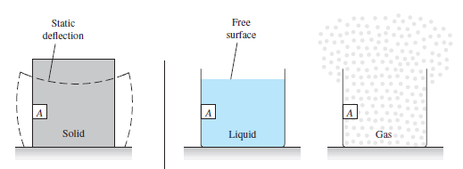

**유체(Fluid)란?**

> *유체(Fluid)*는 지속적으로 변형되는 연속체(Coninuum)이다. 또는 흐를 수 있는 물질로 액체(Liquid)와 기체(Gas)를 아우른다.

유체와 다르게 고체(Solid)는 힘을 받아도 그 힘에 저항하며 본래 형체를 유지할려고 한다.

액체와 기체는 용기에 담을 때 그 용기의 모양에 맞게 형체가 변형한다. 이 두 물질의 차이점은 진공 상태에 있는 용기에 담을 때 액체는 중력에 영향을 받아 용기에 담기며 자유 표면(Free Surface)를 구성하지만 기체는 담기지 않고 용기 외부로 확산(Diffusion)할려고 한다.

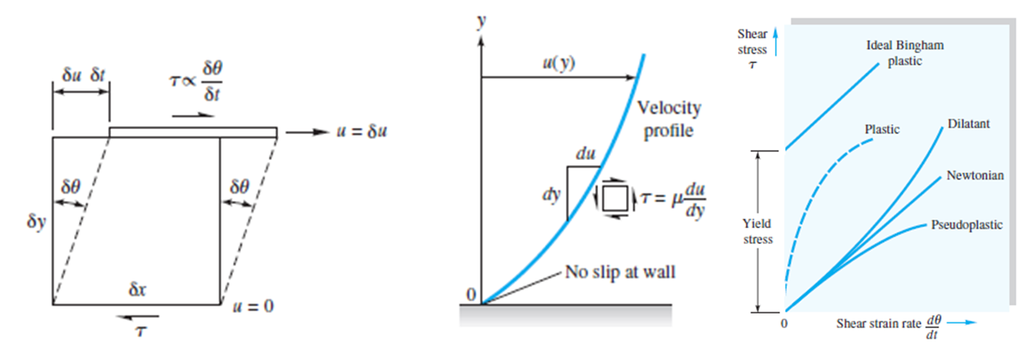

**점도(Viscosity)란?**

> *점도(Viscosity)*는 유체의 끈적한 정도를 물리적으로 표현한 수치이다.

점성(Viscous) 유체는 전단 응력(Shear Stress)이 가해질 시 전단 변형률(Shear Strain)이 지속적으로 발생한다.

$$ \begin{align*} \tan \delta \theta = \frac{ \delta u \cdot \delta t }{ \delta y} \approx \delta \theta && \Longrightarrow && \tau \propto \frac{ \delta \theta }{ \delta t } = \frac{ \delta u }{ \delta y } && \Longrightarrow && \tau = \mu \frac{du}{dy} \end{align*} $$

> $\delta u$는 유체 흐름 속도 (Velocity) $\text{[m/s]}$  
> $\delta \theta$는 전단 변형률 (Shear Strain) $\text{[rad]}$  
> $\tau$는 전단 응력 (Shear Stress) $[\text{N}/\text{m}^2]$  
> $\mu$는 점성 계수 (Dynamic Viscosity) $[\text{N.s}/\text{m}^2]$  
> $du/dy$는 전단률 (Shear Rate) $[1/\text{s}]$

유체의 점성에 따라 두 종류로 나눌 수 있다.

- 뉴턴 유체 (Newtonian Fluid): 전단 응력에 선형 정비례하는 전단률을 가진다.
- 비뉴턴 유체 (Non-Newtonian Fluid): 뉴턴 유체 외 유체를 일컫는다.

## 1.2. 유체의 흐름 (Flow)

### 1.2.1. 흐름의 표현

## 1.3. 검사 체적 (Control Volume)

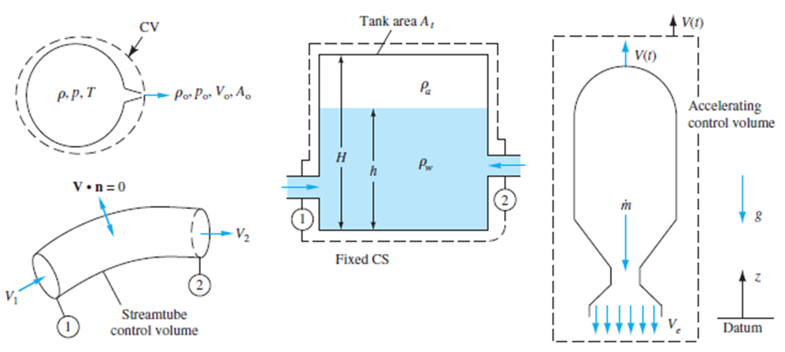

**검사 체적(Control Volume)이란?**

> 검사 체적(Control Volume)은 임의로 설정한 가상의 공간, 또는 계(System)라고 칭하며 고정되어 있거나 유체의 흐름과 동일한 속도로 움직인다. 주로, 질량과 에너지 보존 법칙을 사용할때 쓰인다.

**질량 보존 법칙 (Conservation of Mass)**

$$ \begin{align*} \Delta m_{CV} = \Sigma m_{in} - \Sigma m_{out} && \therefore \quad \frac{dm_{CV}}{dt} = \Sigma \dot{m}_{in} - \Sigma \dot{m}_{out} = \dot{m}_{CV} \end{align*} $$

> $m_{CV}$는 검사 체적 내 질량 $\text{[kg]}$  
> $\dot{m}_{CV}$는 질량 유량 (Mass Rate) $\text{[kg/s]}$

**에너지 보존 법칙 (Conservation of Energy)**

$$ \begin{align*} \Delta E_{CV} = \Sigma E_{in} - \Sigma E_{out} && \therefore \quad \frac{dE_{CV}}{dt} = \frac{dKE}{dt} + \frac{dPE}{dt} + \frac{dU}{dt} = \dot{E}_{CV} \end{align*} $$

> $E_{CV}$는 검사 체적 내 에너지 $\text{[J]}$  
> $\dot{E}_{CV}$는 검사 체적 내 일률 (Power) $\text{[J/s]}$  
> $KE$는 운동에너지 (Kinetic Energy) $\text{[J]}$  
> $PE$는 전위에너지 (Potential Energy) $\text{[J]}$  
> $U$는 내부 에너지 (Internal Energy) $\text{[J]}$

## 1.4. 차원 분석 (Dimensional Analysis)

### 1.4.1. 차원 분석 개념

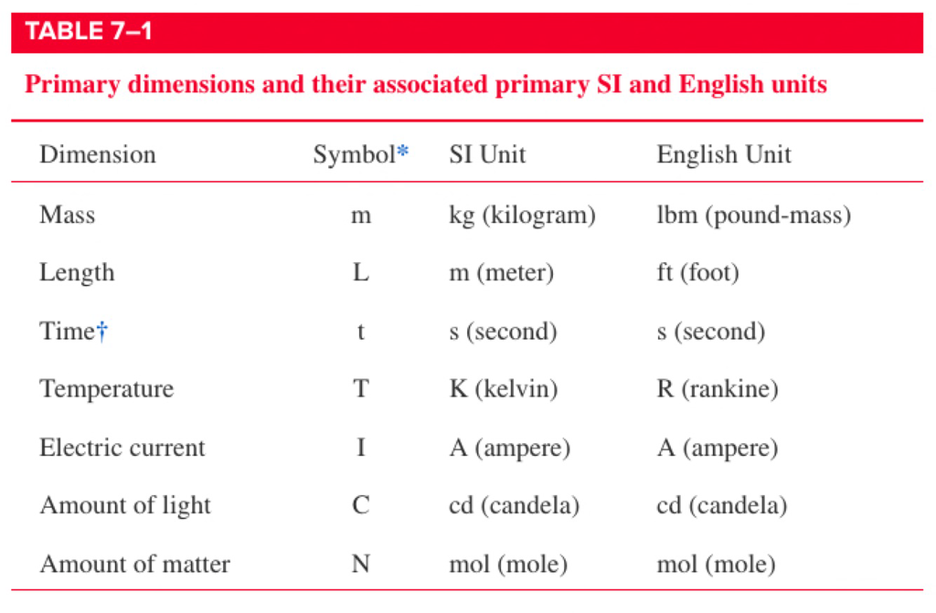

**차원 분석(Dimensional Analysis)이란?**

> *차원 분석(Dimensional Analysis)*은 특정 물리량의 차원을 정의하기 위해 기본적인 도량형으로 분해하는 것이다.

기본적인 도량형은 위 사진처럼 총 일곱가지가 있다.

모든 물리 방정식은 차원 상사성(Dimensional Homogeneity)를 가져야 해석이 가능하다. 좌변과 우변의 항들은 항상 같은 차원을 가져야 한다는 뜻이다.

**무차원화 (Nondimensionalization)**

> *무차원화(Nondimensionalization)*는 차원 분석을 통해 특정 현상으로부터 무차원량을 도출하는 것이다.

유체역학의 경우 실제 현상을 축소 모형으로 만들어 상사성(Similarity)을 띄게 한 뒤 무차원 수를 도출해 크기와 상관 없이 적용시킬 수 있으며 계산해야하는 변수의 수를 줄여준다.

**상사성 (Similarity)**

> *상사성(Similarity)*은 무차원 수로 계산된 모형을 축소/확대가 가능하도록 한다.

상사성을 가질려면 원형(Prototype)과 모형(Model) 사이 세가지 조건이 성립되어야 한다.

- 기하학적 상사성 (Geometric Similarity): 원형과 모형의 형태(Shape) 또는 치수(Dimensions)가 정비례해야한다.
- 운동학적 상사성 (Kinematic Similarity): 원형과 모형의 유속이 정비례해야한다.
- 역학적 상사성 (Dynamic Similarity): 원형과 모형의 힘의 크기가 정비례해야한다.

### 1.4.2. 버킹엄의 파이 정리 (Buckingham's Pi Theorem)

**버킹엄의 파이 정리 (Buckingham's Pi Theorem)**

> *버킹엄의 파이 정리(Buckingham's Pi Theorem)*는 변수를 무차원 파라미터로 묶어 문제의 변수를 줄이는 데 사용된다.

풀이 절차:

1. 문제에 관련된 모든 변수를 나열한다.
2. 모든 변수에 대해 차원 분석을 하여 기본 차원을 식별한다.
3. $n$개 변수에서 $j$개 기본 차원 개수를 뺀 수, $k$개의 무차원 파이 그룹을 형성한다.
4. 서로 독립적인 반복 변수(Repeating Variables)를 선택하여 적절한 지수를 찾아 무차원 조합을 만든다.
5. 조합된 차원이 상수가 되도록 하여 지수를 찾는다.
6. 파이 그룹을 명시적으로 표현한다.
7. 다른 파이 그룹이 남아있다면 1번에서 6번까지 반복한다.

### 1.4.3. 무차원수 (Dimensionless Numbers)

**무차원수 (Dimensionless Numbers)**

> *무차원수(Dimensionless Numbers)*는 크기와 단위와는 관계 없는 차원이 없는 물리량을 말한다.

열유체역학에서 쓰이는 5가지 무차원수를 정리했다.

- 레이놀즈 수, $\text{Re}$ (Reynolds Number):

> *레이놀즈 수(Reynolds Number)*는 유체의 관성력과 점성력의 비율을 나타낸다. 이 수로 층류(Laminar Flow)와 난류(Turbulent Flow)를 판단한다.

$$ \begin{align*} \text{Re} = \frac{ \text{inertial force} }{ \text{viscous force} } = \frac{ \rho u L }{\mu} = \frac{ u L }{\nu} && \end{align*} $$

> $\rho$는 밀도 (Density) $[\text{kg}/\text{m}^3]$  
> $u$는 유속 (Velocity) $[text{m/s}]$  
> $L$은 특성 길이 (Characteristic Length) $[\text{m}]$  
> $\mu$는 점성 계수 (Dynamic Viscosity) $[\text{N.s}/\text{m}^2]$  
> $\nu$는 동점성 계수 (Kinematic Viscosity) $[\text{m}^2/\text{s}]$

특성 길이의 경우 검사 평면(Control Surface)에서의 흐름의 방향대로 해당되는 길이를 뜻한다. 관수로(Pipe)의 경우 수력학적 직경(Hydraulic Diameter), $D_h$를 쓴다.

레이놀즈 수는 층류와 난류를 판별하는 수이다. 관수로 내부 흐름에 대해서 2100 미만의 레이놀즈 수는 층류를 말하고 4000 초과의 레이놀즈 수는 난류를 말한다. 그 사이에 있는 수는 천이 영역(Transient)으로 불리운다. 평판 위의 흐름에 대해서는 임계 레이놀즈 수, $\text{Re}_{cr}$가 있으며 그 수 이하는 층류, 이상은 난류로 구분한다.

$$ \begin{align*} \text{In a pipe,} \\ \\ \text{Re} &< 2100 \quad \text{for laminar flow} \\ \\ 2100 \leq \text{Re} &\leq 4000 \quad \text{for transient flow} \\ \\ \text{Re} &> 4000 \quad \text{for turbulent flow} \\ \\ \text{On a plate,} \\ \\ \text{Re} &< \text{Re}_{cr} \approx 10^5 \quad \text{for laminar flow} \\ \\ \text{Re} &> \text{Re}_{cr} \approx 10^5 \quad \text{for turbulent flow} \end{align*} $$

- 마하 수, $\text{Ma}$ (Mach Number):

> *마하 수(Mach Number)*는 유체의 압축성의 척도로 사용된다.

$$ \begin{align*} \text{Ma} = \frac{ \text{flow velocity} }{ \text{speed of sound} } = \frac{u}{c} \end{align*} $$

> $c$는 음속 (Speed of Sound) $[\text{m/s}]$

마하 0.3 이하의 유동은 비압축성(Incompressible)으로 분류된다.

$$ \begin{align*} \text{Ma} < 0.3 \quad \text{for incompressible flow} \end{align*} $$

- 프란틀 수, $\text{Pr}$ (Prandtl Number):

> *프란틀 수(Prandtl Number)*는 점성에 따른 대류열의 전달 정도를 파악하는 데 사용된다.

$$ \begin{align*} \text{Pr} = \frac{ \text{viscous diffusion rate} }{ \text{thermal diffusion rate} } = \frac{\nu}{\alpha} = \frac{ c_p \mu }{k} \end{align*} $$

> $\alpha$는 열확산 계수 (Thermal Diffusivity) $[\text{m}^2/\text{s}]$  
> $c_p$는 비열용량 (Specific Heat) $[\text{J/kg.K}]$  
> $k$는 열전도율 (Thermal Conductivity) $[\text{W/m.K}]$

프란틀 수는 낮을 수록 열이 효율적으로 퍼지고 높을 수록 단열이 된다.

- 프루드 수, $\text{Fr}$ (Froude Number):

> *프루드 수(Foude Number)*는 자유 표면을 가지는 유동의 형태를 판별하는 데에 사용된다.

$$ \begin{align*} \text{Fr} = \frac{ \text{inertial force} }{ \text{gravitational force} } = \frac{u}{ \sqrt{ gL } } \end{align*} $$

이 값이 1 이상인 흐름을 사류(Supercritical Flow), 1 이하인 흐름을 상류(Subcritical Flow)라고 한다.

- 너셀 수, $\text{Nu}$ (Nusselt Number):

$$ \begin{align*} \text{Nu} = \frac{ \text{convection} }{ \text{conduction} } = \frac{ h L }{ k } \end{align*} $$

> $h$는 열전달 계수 (Convection Heat Transfer Coefficient) $[\text{W}/\text{m}^2 \text{.K}]$

## 1.5. 전제 (Assumptions)

# 3. 유체동역학 (Fluid Dynamics)

## 3.1. 베르누이 정리 (Bernouilli Equation)

**베르누이 정리 (Bernouilli Equation)**

> *베르누이 정리 (Bernouilli Equation)*는 유체가 규칙적으로 흐르는 것에 대한 속력, 압력, 높이의 관계에 대한 법칙이다.

$$ \begin{align*} P + \frac{1}{2} \rho v^2 + \rho g h = \text{const.} \end{align*} $$

## 3.2. 레이놀즈 수송 정리 (Reynold's Transport Theorem)

## 3.3. 연속 방정식 (Continuity Equation)

## 3.4. 나비에-스톡스 방정식 (Navier-Stokes Equation)